# Assignment

Name: Kunal Singhal University Roll No. : 2315510107 Section: CB

**Assignment Title:** End-to-End ANN Model Implementation and Analysis Instructions:

1. Follow the tasks step by step in this notebook.
2. Write your code in the provided cells only.
3. Submit the following:

   Completed .ipynb file

**A report (.pdf or .docx) with answers to the analysis questions provided at the end.**

✅ Task 1: Import Required Libraries

```python
import numpy as np
import pandas as pd
import matplotlib.pyplot as plt
import seaborn as sns

from sklearn.model_selection import train_test_split
from sklearn.preprocessing import StandardScaler
from sklearn.metrics import mean_absolute_error,mean_squared_error,r2_score
```

```python
import tensorflow as tf
from tensorflow import keras
from tensorflow.keras.models import Sequential
from tensorflow.keras.layers import Dense
```

✅ Task 2: Load Dataset (Use from sklearn.datasets or any open dataset)

```python
df = pd.read_csv("Dataset.csv")
```

```python
df.head()
```

|  | Surname | CreditScore | Age | Tenure | Balance | NumOfProducts | HasCrCard | IsActiveMember | EstimatedSalary | Exited | ... | France | Germany | Spain | Female | Male | Mem__no__Products | Cred_Bal_Sal | Bal_sal | Tenure_Age | Age_Tenure_product |
| --- | --- | --- | --- | --- | --- | --- | --- | --- | --- | --- | --- | --- | --- | --- | --- | --- | --- | --- | --- | --- | --- |
| 0 | 2023 | 668.0 | 33.0 | 3.0 | 0.00 | 2.0 | 1 | 0 | 181449.97 | 0 | ... | 1 | 0 | 0 | 0 | 1 | 0.0 | 0.000000 | 0.000000 | 0.090909 | 99.0 |
| 1 | 2024 | 627.0 | 33.0 | 1.0 | 0.00 | 2.0 | 1 | 1 | 49503.50 | 0 | ... | 1 | 0 | 0 | 0 | 1 | 2.0 | 0.000000 | 0.000000 | 0.030303 | 33.0 |
| 2 | 1236 | 678.0 | 40.0 | 10.0 | 0.00 | 2.0 | 1 | 0 | 184866.69 | 0 | ... | 1 | 0 | 0 | 0 | 1 | 0.0 | 0.000000 | 0.000000 | 0.250000 | 400.0 |
| 3 | 1362 | 581.0 | 34.0 | 2.0 | 148882.54 | 1.0 | 1 | 1 | 84560.88 | 0 | ... | 1 | 0 | 0 | 0 | 1 | 1.0 | 1022.940581 | 1.760655 | 0.058824 | 68.0 |
| 4 | 491 | 716.0 | 33.0 | 5.0 | 0.00 | 2.0 | 1 | 1 | 15068.83 | 0 | ... | 0 | 0 | 1 | 0 | 1 | 2.0 | 0.000000 | 0.000000 | 0.151515 | 165.0 |

5 rows × 25 columns

```python
df.tail()
```

|  | Surname | CreditScore | Age | Tenure | Balance | NumOfProducts | HasCrCard | IsActiveMember | EstimatedSalary | Exited | ... | France | Germany | Spain | Female | Male | Mem__no__Products | Cred_Bal_Sal | Bal_sal | Tenure_Age | Age_Tenure_product |
| --- | --- | --- | --- | --- | --- | --- | --- | --- | --- | --- | --- | --- | --- | --- | --- | --- | --- | --- | --- | --- | --- |
| 175023 | 2226 | 644.0 | 28.0 | 7.0 | 155060.41 | 1.0 | 1 | 0 | 29179.52 | 0 | ... | 1 | 0 | 0 | 0 | 1 | 0.0 | 3422.225727 | 5.314015 | 0.250000 | 196.0 |
| 175024 | 2846 | 800.0 | 29.0 | 2.0 | 0.00 | 2.0 | 0 | 0 | 167773.55 | 0 | ... | 1 | 0 | 0 | 1 | 0 | 0.0 | 0.000000 | 0.000000 | 0.068966 | 58.0 |
| 175025 | 1999 | 771.0 | 39.0 | 5.0 | 0.00 | 2.0 | 1 | 0 | 96270.64 | 0 | ... | 1 | 0 | 0 | 0 | 1 | 0.0 | 0.000000 | 0.000000 | 0.128205 | 195.0 |
| 175026 | 1336 | 516.0 | 35.0 | 10.0 | 57369.61 | 1.0 | 1 | 1 | 101699.77 | 0 | ... | 1 | 0 | 0 | 0 | 1 | 1.0 | 291.079505 | 0.564108 | 0.285714 | 350.0 |
| 175027 | 1570 | 709.0 | 36.0 | 7.0 | 0.00 | 1.0 | 0 | 1 | 42085.58 | 1 | ... | 1 | 0 | 0 | 1 | 0 | 1.0 | 0.000000 | 0.000000 | 0.194444 | 252.0 |

5 rows × 25 columns

✅ Task 3: Perform Exploratory Data Analysis (EDA)

1. Show basic info (shape, columns, datatypes)
2. Describe data
3. Use visualizations (histograms, boxplots, heatmaps, pairplots etc.)

Identify class imbalance if any

```python
df.shape
```

```
(175028, 25)
```

```python
df.info()
```

```
<class 'pandas.core.frame.DataFrame'>
RangeIndex: 175028 entries, 0 to 175027
Data columns (total 25 columns):
 #   Column              Non-Null Count   Dtype
---  ------              --------------   -----
 0   Surname             175028 non-null  int64
 1   CreditScore         175028 non-null  float64
 2   Age                 175028 non-null  float64
 3   Tenure              175028 non-null  float64
 4   Balance             175028 non-null  float64
 5   NumOfProducts       175028 non-null  float64
 6   HasCrCard           175028 non-null  int64
 7   IsActiveMember      175028 non-null  int64
 8   EstimatedSalary     175028 non-null  float64
 9   Exited              175028 non-null  int64
```

[output cut: 17 more lines]

```python
df.describe()
```

|  | Surname | CreditScore | Age | Tenure | Balance | NumOfProducts | HasCrCard | IsActiveMember | EstimatedSalary | Exited | ... | France | Germany | Spain | Female | Male | Mem__no__Products | Cred_Bal_Sal | Bal_sal | Tenure_Age | Age_Tenure_product |
| --- | --- | --- | --- | --- | --- | --- | --- | --- | --- | --- | --- | --- | --- | --- | --- | --- | --- | --- | --- | --- | --- |
| count | 175028.000000 | 175028.000000 | 175028.000000 | 175028.000000 | 175028.000000 | 175028.000000 | 175028.000000 | 175028.000000 | 175028.000000 | 175028.000000 | ... | 175028.000000 | 175028.000000 | 175028.000000 | 175028.000000 | 175028.000000 | 175028.000000 | 1.750280e+05 | 175028.000000 | 175028.000000 | 175028.000000 |
| mean | 1617.462812 | 656.113068 | 38.171337 | 5.019968 | 56676.772103 | 1.553072 | 0.751183 | 0.498754 | 111863.295024 | 0.211149 | ... | 0.566909 | 0.212046 | 0.221045 | 0.436644 | 0.563356 | 0.784989 | 1.444363e+03 | 2.202494 | 0.138587 | 191.346929 |
| std | 813.852174 | 81.148273 | 8.969565 | 2.811155 | 62982.418525 | 0.549212 | 0.432329 | 0.500000 | 50815.118428 | 0.408125 | ... | 0.495504 | 0.408758 | 0.414952 | 0.495971 | 0.495971 | 0.871599 | 6.097238e+04 | 92.679435 | 0.085465 | 118.745788 |
| min | 0.000000 | 350.000000 | 18.000000 | 0.000000 | 0.000000 | 1.000000 | 0.000000 | 0.000000 | 11.580000 | 0.000000 | ... | 0.000000 | 0.000000 | 0.000000 | 0.000000 | 0.000000 | 0.000000 | 0.000000e+00 | 0.000000 | 0.000000 | 0.000000 |
| 25% | 949.000000 | 597.000000 | 32.000000 | 3.000000 | 0.000000 | 1.000000 | 1.000000 | 0.000000 | 73225.310000 | 0.000000 | ... | 0.000000 | 0.000000 | 0.000000 | 0.000000 | 0.000000 | 0.000000 | 0.000000e+00 | 0.000000 | 0.068182 | 93.000000 |
| 50% | 1666.000000 | 659.000000 | 37.000000 | 5.000000 | 0.000000 | 2.000000 | 1.000000 | 0.000000 | 116969.730000 | 0.000000 | ... | 1.000000 | 0.000000 | 0.000000 | 0.000000 | 1.000000 | 0.000000 | 0.000000e+00 | 0.000000 | 0.131579 | 180.000000 |
| 75% | 2292.000000 | 710.000000 | 42.000000 | 7.000000 | 120727.970000 | 2.000000 | 1.000000 | 1.000000 | 154767.340000 | 0.000000 | ... | 1.000000 | 0.000000 | 0.000000 | 1.000000 | 1.000000 | 2.000000 | 6.585861e+02 | 1.000001 | 0.200000 | 272.000000 |
| max | 2931.000000 | 850.000000 | 92.000000 | 10.000000 | 250898.090000 | 4.000000 | 1.000000 | 1.000000 | 199992.480000 | 1.000000 | ... | 1.000000 | 1.000000 | 1.000000 | 1.000000 | 1.000000 | 4.000000 | 8.634204e+06 | 12863.796200 | 0.555556 | 880.000000 |

8 rows × 25 columns

```python
df.columns
```

```
Index(['Surname', 'CreditScore', 'Age', 'Tenure', 'Balance', 'NumOfProducts',
       'HasCrCard', 'IsActiveMember', 'EstimatedSalary', 'Exited',
       'Surname_tfidf_0', 'Surname_tfidf_1', 'Surname_tfidf_2',
       'Surname_tfidf_3', 'Surname_tfidf_4', 'France', 'Germany', 'Spain',
       'Female', 'Male', 'Mem__no__Products', 'Cred_Bal_Sal', 'Bal_sal',
       'Tenure_Age', 'Age_Tenure_product'],
      dtype='object')
```

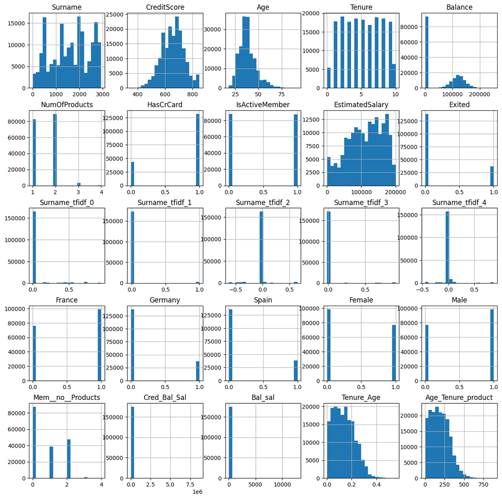

```python
df.hist(bins=20,figsize=(15,15))
plt.show()
```

[figure not shown]

```python
df.boxplot(figsize=(20,10))
plt.show()
```

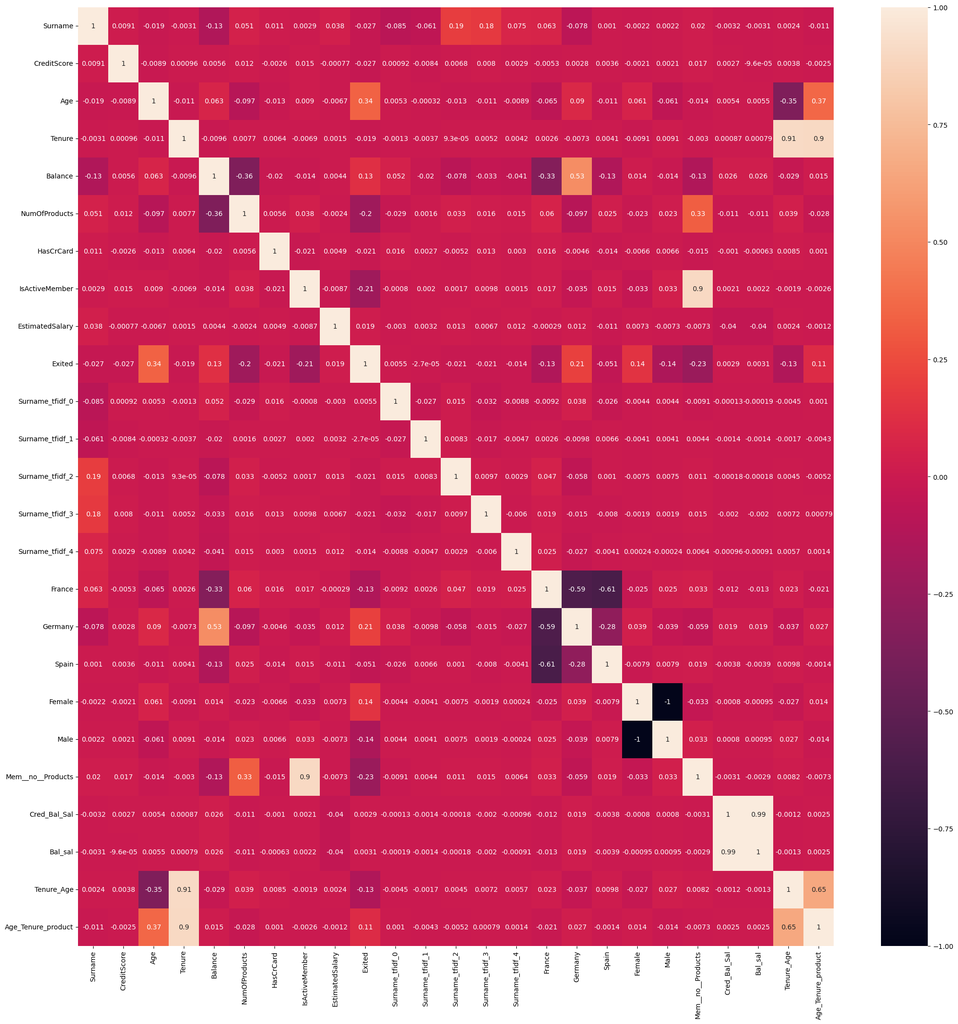

```python
corr_matrix = df.corr(numeric_only=True)
plt.figure(figsize=(25, 25))
sns.heatmap(corr_matrix,annot=True,)
plt.show()
```

✅ Task 4: Feature Engineering

1. Handle missing values if any
2. Encode categorical variables if any
3. Create or remove irrelevant features

```python
df.isnull().sum()
```

```
Surname               0
CreditScore           0
Age                   0
Tenure                0
Balance               0
NumOfProducts         0
HasCrCard             0
IsActiveMember        0
EstimatedSalary       0
Exited                0
Surname_tfidf_0       0
Surname_tfidf_1       0
Surname_tfidf_2       0
Surname_tfidf_3       0
Surname_tfidf_4       0
France                0
Germany               0
Spain                 0
Female                0
Male                  0
Mem__no__Products     0
Cred_Bal_Sal          0
Bal_sal               0
Tenure_Age            0
Age_Tenure_product    0
dtype: int64
```

```
Exited
0    138071
1     36957
Name: count, dtype: int64
```

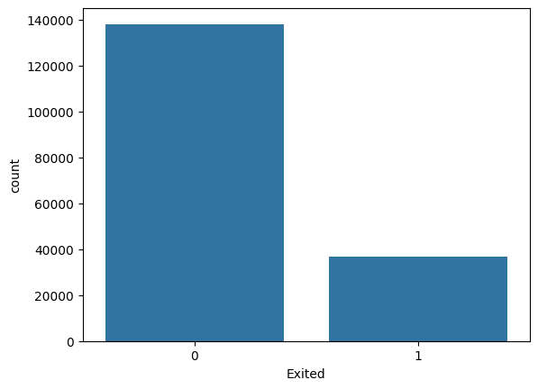

```python
sns.countplot(x='Exited',data=df)
df['Exited'].value_counts()
```

✅ Task 5: Feature Scaling / Normalization

1. StandardScaler / MinMaxScaler

✅ Task 6: Split Data into Training and Testing Sets (80/20 or 70/30)

```python
X = df.drop(['Exited'],axis=1)
y = df['Exited']
```

```python
X_train,X_test,y_train,y_test = train_test_split(X,y,test_size=0.2,random_state=42)
```

```python
X_test.shape
```

[output not shown]

```python
sc = StandardScaler()
X_train = sc.fit_transform(X_train)
X_test = sc.transform(X_test)
```

✅ Task 7: Define the ANN Model (Sequential API - Keras)

1. Design architecture (input, hidden, output layers)
2. Use appropriate activation functions

```python
model = Sequential([
    Dense(128,activation='relu'),
    Dense(64,activation='relu'),
    Dense(32,activation='relu'),
    Dense(1,activation='sigmoid')
])
```

```python
model.summary()
```

```
Model: "sequential_5"
```

```
┏━━━━━━━━━━━━━━━━━━━━━━━━━━━━━━━━━┳━━━━━━━━━━━━━━━━━━━━━━━━┳━━━━━━━━━━━━━━━┓
┃ Layer (type)                    ┃ Output Shape           ┃       Param # ┃
┡━━━━━━━━━━━━━━━━━━━━━━━━━━━━━━━━━╇━━━━━━━━━━━━━━━━━━━━━━━━╇━━━━━━━━━━━━━━━┩
│ dense_20 (Dense)                │ ?                      │   0 (unbuilt) │
├─────────────────────────────────┼────────────────────────┼───────────────┤
│ dense_21 (Dense)                │ ?                      │   0 (unbuilt) │
├─────────────────────────────────┼────────────────────────┼───────────────┤
│ dense_22 (Dense)                │ ?                      │   0 (unbuilt) │
├─────────────────────────────────┼────────────────────────┼───────────────┤
│ dense_23 (Dense)                │ ?                      │   0 (unbuilt) │
└─────────────────────────────────┴────────────────────────┴───────────────┘
```

```
 Total params: 0 (0.00 B)
```

```
 Trainable params: 0 (0.00 B)
```

```
 Non-trainable params: 0 (0.00 B)
```

✅ Task 8: Compile the Model

- Select optimizer, loss function, and evaluation metrics

```python
model.compile(optimizer='adam',loss='binary_crossentropy',metrics=['accuracy'])
```

✅ Task 9: Train the Model

- Use model.fit()
- Track performance using training history

```python
m = model.fit(X_train, y_train, epochs=50, validation_split=0.2)
```

```
3501/3501 ━━━━━━━━━━━━━━━━━━━━ 10s 2ms/step - accuracy: 0.8551 - loss: 0.3436 - val_accuracy: 0.8617 - val_loss: 0.3324
3501/3501 ━━━━━━━━━━━━━━━━━━━━ 14s 4ms/step - accuracy: 0.8624 - loss: 0.3282 - val_accuracy: 0.8619 - val_loss: 0.3333
3501/3501 ━━━━━━━━━━━━━━━━━━━━ 14s 4ms/step - accuracy: 0.8637 - loss: 0.3264 - val_accuracy: 0.8605 - val_loss: 0.3307
3501/3501 ━━━━━━━━━━━━━━━━━━━━ 14s 4ms/step - accuracy: 0.8644 - loss: 0.3250 - val_accuracy: 0.8620 - val_loss: 0.3309
3501/3501 ━━━━━━━━━━━━━━━━━━━━ 14s 4ms/step - accuracy: 0.8647 - loss: 0.3238 - val_accuracy: 0.8621 - val_loss: 0.3304
3501/3501 ━━━━━━━━━━━━━━━━━━━━ 7s 2ms/step - accuracy: 0.8646 - loss: 0.3232 - val_accuracy: 0.8633 - val_loss: 0.3279
3501/3501 ━━━━━━━━━━━━━━━━━━━━ 7s 2ms/step - accuracy: 0.8650 - loss: 0.3222 - val_accuracy: 0.8638 - val_loss: 0.3276
3501/3501 ━━━━━━━━━━━━━━━━━━━━ 13s 4ms/step - accuracy: 0.8645 - loss: 0.3216 - val_accuracy: 0.8619 - val_loss: 0.3304
3501/3501 ━━━━━━━━━━━━━━━━━━━━ 14s 4ms/step - accuracy: 0.8652 - loss: 0.3207 - val_accuracy: 0.8629 - val_loss: 0.3280
3501/3501 ━━━━━━━━━━━━━━━━━━━━ 14s 4ms/step - accuracy: 0.8658 - loss: 0.3201 - val_accuracy: 0.8630 - val_loss: 0.3287
3501/3501 ━━━━━━━━━━━━━━━━━━━━ 14s 4ms/step - accuracy: 0.8657 - loss: 0.3195 - val_accuracy: 0.8625 - val_loss: 0.3277
3501/3501 ━━━━━━━━━━━━━━━━━━━━ 7s 2ms/step - accuracy: 0.8661 - loss: 0.3191 - val_accuracy: 0.8634 - val_loss: 0.3286
3501/3501 ━━━━━━━━━━━━━━━━━━━━ 13s 4ms/step - accuracy: 0.8664 - loss: 0.3183 - val_accuracy: 0.8621 - val_loss: 0.3284
3501/3501 ━━━━━━━━━━━━━━━━━━━━ 16s 5ms/step - accuracy: 0.8666 - loss: 0.3176 - val_accuracy: 0.8636 - val_loss: 0.3296
3501/3501 ━━━━━━━━━━━━━━━━━━━━ 7s 2ms/step - accuracy: 0.8668 - loss: 0.3169 - val_accuracy: 0.8641 - val_loss: 0.3279
3501/3501 ━━━━━━━━━━━━━━━━━━━━ 6s 2ms/step - accuracy: 0.8675 - loss: 0.3164 - val_accuracy: 0.8640 - val_loss: 0.3281
3501/3501 ━━━━━━━━━━━━━━━━━━━━ 6s 2ms/step - accuracy: 0.8671 - loss: 0.3162 - val_accuracy: 0.8601 - val_loss: 0.3317
3501/3501 ━━━━━━━━━━━━━━━━━━━━ 6s 2ms/step - accuracy: 0.8674 - loss: 0.3149 - val_accuracy: 0.8622 - val_loss: 0.3326
3501/3501 ━━━━━━━━━━━━━━━━━━━━ 6s 2ms/step - accuracy: 0.8678 - loss: 0.3147 - val_accuracy: 0.8622 - val_loss: 0.3305
3501/3501 ━━━━━━━━━━━━━━━━━━━━ 10s 1ms/step - accuracy: 0.8684 - loss: 0.3136 - val_accuracy: 0.8621 - val_loss: 0.3308
3501/3501 ━━━━━━━━━━━━━━━━━━━━ 6s 2ms/step - accuracy: 0.8677 - loss: 0.3133 - val_accuracy: 0.8626 - val_loss: 0.3298
3501/3501 ━━━━━━━━━━━━━━━━━━━━ 7s 2ms/step - accuracy: 0.8680 - loss: 0.3122 - val_accuracy: 0.8611 - val_loss: 0.3328
3501/3501 ━━━━━━━━━━━━━━━━━━━━ 6s 2ms/step - accuracy: 0.8690 - loss: 0.3118 - val_accuracy: 0.8618 - val_loss: 0.3320
3501/3501 ━━━━━━━━━━━━━━━━━━━━ 6s 2ms/step - accuracy: 0.8690 - loss: 0.3115 - val_accuracy: 0.8617 - val_loss: 0.3338
3501/3501 ━━━━━━━━━━━━━━━━━━━━ 6s 2ms/step - accuracy: 0.8690 - loss: 0.3103 - val_accuracy: 0.8610 - val_loss: 0.3336
3501/3501 ━━━━━━━━━━━━━━━━━━━━ 7s 2ms/step - accuracy: 0.8696 - loss: 0.3098 - val_accuracy: 0.8613 - val_loss: 0.3346
3501/3501 ━━━━━━━━━━━━━━━━━━━━ 7s 2ms/step - accuracy: 0.8701 - loss: 0.3089 - val_accuracy: 0.8631 - val_loss: 0.3357
3501/3501 ━━━━━━━━━━━━━━━━━━━━ 10s 2ms/step - accuracy: 0.8695 - loss: 0.3083 - val_accuracy: 0.8617 - val_loss: 0.3376
3501/3501 ━━━━━━━━━━━━━━━━━━━━ 7s 2ms/step - accuracy: 0.8700 - loss: 0.3077 - val_accuracy: 0.8611 - val_loss: 0.3353
3501/3501 ━━━━━━━━━━━━━━━━━━━━ 6s 2ms/step - accuracy: 0.8707 - loss: 0.3069 - val_accuracy: 0.8612 - val_loss: 0.3357
3501/3501 ━━━━━━━━━━━━━━━━━━━━ 6s 2ms/step - accuracy: 0.8714 - loss: 0.3063 - val_accuracy: 0.8591 - val_loss: 0.3434
3501/3501 ━━━━━━━━━━━━━━━━━━━━ 6s 2ms/step - accuracy: 0.8706 - loss: 0.3056 - val_accuracy: 0.8592 - val_loss: 0.3379
3501/3501 ━━━━━━━━━━━━━━━━━━━━ 14s 4ms/step - accuracy: 0.8720 - loss: 0.3051 - val_accuracy: 0.8592 - val_loss: 0.3393
3501/3501 ━━━━━━━━━━━━━━━━━━━━ 14s 4ms/step - accuracy: 0.8719 - loss: 0.3042 - val_accuracy: 0.8593 - val_loss: 0.3393
3501/3501 ━━━━━━━━━━━━━━━━━━━━ 14s 4ms/step - accuracy: 0.8717 - loss: 0.3035 - val_accuracy: 0.8610 - val_loss: 0.3395
3501/3501 ━━━━━━━━━━━━━━━━━━━━ 15s 4ms/step - accuracy: 0.8721 - loss: 0.3029 - val_accuracy: 0.8607 - val_loss: 0.3397
3501/3501 ━━━━━━━━━━━━━━━━━━━━ 15s 4ms/step - accuracy: 0.8722 - loss: 0.3024 - val_accuracy: 0.8578 - val_loss: 0.3432
3501/3501 ━━━━━━━━━━━━━━━━━━━━ 12s 4ms/step - accuracy: 0.8725 - loss: 0.3015 - val_accuracy: 0.8600 - val_loss: 0.3441
3501/3501 ━━━━━━━━━━━━━━━━━━━━ 14s 2ms/step - accuracy: 0.8727 - loss: 0.3011 - val_accuracy: 0.8577 - val_loss: 0.3434
3501/3501 ━━━━━━━━━━━━━━━━━━━━ 6s 2ms/step - accuracy: 0.8734 - loss: 0.3006 - val_accuracy: 0.8604 - val_loss: 0.3443
3501/3501 ━━━━━━━━━━━━━━━━━━━━ 6s 2ms/step - accuracy: 0.8733 - loss: 0.2996 - val_accuracy: 0.8598 - val_loss: 0.3449
3501/3501 ━━━━━━━━━━━━━━━━━━━━ 6s 2ms/step - accuracy: 0.8737 - loss: 0.2988 - val_accuracy: 0.8577 - val_loss: 0.3465
3501/3501 ━━━━━━━━━━━━━━━━━━━━ 6s 2ms/step - accuracy: 0.8744 - loss: 0.2983 - val_accuracy: 0.8577 - val_loss: 0.3492
3501/3501 ━━━━━━━━━━━━━━━━━━━━ 6s 2ms/step - accuracy: 0.8738 - loss: 0.2978 - val_accuracy: 0.8573 - val_loss: 0.3451
3501/3501 ━━━━━━━━━━━━━━━━━━━━ 6s 2ms/step - accuracy: 0.8737 - loss: 0.2975 - val_accuracy: 0.8570 - val_loss: 0.3514
3501/3501 ━━━━━━━━━━━━━━━━━━━━ 6s 2ms/step - accuracy: 0.8745 - loss: 0.2968 - val_accuracy: 0.8590 - val_loss: 0.3482
3501/3501 ━━━━━━━━━━━━━━━━━━━━ 6s 2ms/step - accuracy: 0.8747 - loss: 0.2960 - val_accuracy: 0.8590 - val_loss: 0.3517
3501/3501 ━━━━━━━━━━━━━━━━━━━━ 6s 2ms/step - accuracy: 0.8750 - loss: 0.2968 - val_accuracy: 0.8583 - val_loss: 0.3498
3501/3501 ━━━━━━━━━━━━━━━━━━━━ 6s 2ms/step - accuracy: 0.8758 - loss: 0.2948 - val_accuracy: 0.8562 - val_loss: 0.3538
3501/3501 ━━━━━━━━━━━━━━━━━━━━ 6s 2ms/step - accuracy: 0.8760 - loss: 0.2944 - val_accuracy: 0.8570 - val_loss: 0.3539
```

```python
model.summary()
```

```
Model: "sequential_5"
```

```
┏━━━━━━━━━━━━━━━━━━━━━━━━━━━━━━━━━┳━━━━━━━━━━━━━━━━━━━━━━━━┳━━━━━━━━━━━━━━━┓
┃ Layer (type)                    ┃ Output Shape           ┃       Param # ┃
┡━━━━━━━━━━━━━━━━━━━━━━━━━━━━━━━━━╇━━━━━━━━━━━━━━━━━━━━━━━━╇━━━━━━━━━━━━━━━┩
│ dense_20 (Dense)                │ (None, 128)            │         3,200 │
├─────────────────────────────────┼────────────────────────┼───────────────┤
│ dense_21 (Dense)                │ (None, 64)             │         8,256 │
├─────────────────────────────────┼────────────────────────┼───────────────┤
│ dense_22 (Dense)                │ (None, 32)             │         2,080 │
├─────────────────────────────────┼────────────────────────┼───────────────┤
│ dense_23 (Dense)                │ (None, 1)              │            33 │
└─────────────────────────────────┴────────────────────────┴───────────────┘
```

```
 Total params: 40,709 (159.02 KB)
```

```
 Trainable params: 13,569 (53.00 KB)
```

```
 Non-trainable params: 0 (0.00 B)
```

```
 Optimizer params: 27,140 (106.02 KB)
```

✅ Task 10: Visualize Model Performance

- Plot loss and accuracy curves for training and validation

[figure not shown]

```python
plt.figure(figsize=(6,3))
plt.subplot(1, 2, 1)
plt.plot(m.history['accuracy'], label='Training Accuracy')
plt.plot(m.history['val_accuracy'], label='Validation Accuracy')
plt.title('Model Accuracy')
plt.xlabel('Epoch')
plt.ylabel('Accuracy')
plt.legend()
plt.subplot(1, 2, 2)
plt.plot(m.history['loss'], label='Training Loss')
plt.plot(m.history['val_loss'], label='Validation Loss')
plt.title('Model Loss')
plt.xlabel('Epoch')
plt.ylabel('Loss')
plt.legend()
plt.tight_layout()
plt.show()
```

✅ Task 11: Evaluate Model on Test Data

- Accuracy, loss
- Predict test set

```python
loss, mae = model.evaluate(X_test,y_test)
```

```
1094/1094 ━━━━━━━━━━━━━━━━━━━━ 2s 1ms/step - accuracy: 0.8591 - loss: 0.3481
```

```python
y_pred = model.predict(X_test)
```

```
1094/1094 ━━━━━━━━━━━━━━━━━━━━ 1s 917us/step
```

- Use sklearn metrics to analyze performance

```python
mse = mean_squared_error(y_test, y_pred)
mse
```

```
0.10393407940864563
```

```python
mae = mean_absolute_error(y_test, y_pred)
mae
```

```
0.1914944052696228
```

```python
rmse = np.sqrt(mse)
rmse
```

```
np.float64(0.32238808819285747)
```

```python
r2 = r2_score(y_test, y_pred)
r2
```

```
0.3765411376953125
```

✅ Task 13: Hyperparameter Tuning (Try any of the following)

- Vary batch size, epochs, optimizers
- Use Keras Tuner or manual tuning

```python
model = Sequential([
    Dense(128,activation='relu', input_shape=(X_train.shape[1],)),
    Dense(32,activation='relu'),
    Dense(1,activation='sigmoid')
])
```

```
c:\Users\This PC\Desktop\DeepLearning\.venv\Lib\site-packages\keras\src\layers\core\dense.py:92: UserWarning: Do not pass an `input_shape`/`input_dim` argument to a layer. When using Sequential models, prefer using an `Input(shape)` object as the first layer in the model instead.
  super().__init__(activity_regularizer=activity_regularizer, **kwargs)
```

```python
model.compile(optimizer='adam',loss='binary_crossentropy',metrics=['accuracy'])
model.summary()
```

```
Model: "sequential_7"
```

```
┏━━━━━━━━━━━━━━━━━━━━━━━━━━━━━━━━━┳━━━━━━━━━━━━━━━━━━━━━━━━┳━━━━━━━━━━━━━━━┓
┃ Layer (type)                    ┃ Output Shape           ┃       Param # ┃
┡━━━━━━━━━━━━━━━━━━━━━━━━━━━━━━━━━╇━━━━━━━━━━━━━━━━━━━━━━━━╇━━━━━━━━━━━━━━━┩
│ dense_28 (Dense)                │ (None, 128)            │         3,200 │
├─────────────────────────────────┼────────────────────────┼───────────────┤
│ dense_29 (Dense)                │ (None, 32)             │         4,128 │
├─────────────────────────────────┼────────────────────────┼───────────────┤
│ dense_30 (Dense)                │ (None, 1)              │            33 │
└─────────────────────────────────┴────────────────────────┴───────────────┘
```

```
 Total params: 7,361 (28.75 KB)
```

```
 Trainable params: 7,361 (28.75 KB)
```

```
 Non-trainable params: 0 (0.00 B)
```

```python
m = model.fit(X_train, y_train, epochs=30, validation_split=0.2)
```

```
3501/3501 ━━━━━━━━━━━━━━━━━━━━ 7s 2ms/step - accuracy: 0.8546 - loss: 0.3448 - val_accuracy: 0.8606 - val_loss: 0.3350
3501/3501 ━━━━━━━━━━━━━━━━━━━━ 6s 2ms/step - accuracy: 0.8620 - loss: 0.3296 - val_accuracy: 0.8610 - val_loss: 0.3300
3501/3501 ━━━━━━━━━━━━━━━━━━━━ 5s 2ms/step - accuracy: 0.8631 - loss: 0.3271 - val_accuracy: 0.8627 - val_loss: 0.3303
3501/3501 ━━━━━━━━━━━━━━━━━━━━ 5s 2ms/step - accuracy: 0.8631 - loss: 0.3252 - val_accuracy: 0.8630 - val_loss: 0.3287
3501/3501 ━━━━━━━━━━━━━━━━━━━━ 5s 1ms/step - accuracy: 0.8644 - loss: 0.3242 - val_accuracy: 0.8625 - val_loss: 0.3299
3501/3501 ━━━━━━━━━━━━━━━━━━━━ 5s 2ms/step - accuracy: 0.8647 - loss: 0.3235 - val_accuracy: 0.8641 - val_loss: 0.3278
3501/3501 ━━━━━━━━━━━━━━━━━━━━ 5s 1ms/step - accuracy: 0.8650 - loss: 0.3228 - val_accuracy: 0.8629 - val_loss: 0.3296
3501/3501 ━━━━━━━━━━━━━━━━━━━━ 5s 1ms/step - accuracy: 0.8650 - loss: 0.3224 - val_accuracy: 0.8625 - val_loss: 0.3297
3501/3501 ━━━━━━━━━━━━━━━━━━━━ 5s 1ms/step - accuracy: 0.8650 - loss: 0.3215 - val_accuracy: 0.8628 - val_loss: 0.3279
3501/3501 ━━━━━━━━━━━━━━━━━━━━ 6s 2ms/step - accuracy: 0.8659 - loss: 0.3208 - val_accuracy: 0.8630 - val_loss: 0.3275
3501/3501 ━━━━━━━━━━━━━━━━━━━━ 5s 2ms/step - accuracy: 0.8660 - loss: 0.3200 - val_accuracy: 0.8613 - val_loss: 0.3303
3501/3501 ━━━━━━━━━━━━━━━━━━━━ 5s 2ms/step - accuracy: 0.8661 - loss: 0.3199 - val_accuracy: 0.8632 - val_loss: 0.3281
3501/3501 ━━━━━━━━━━━━━━━━━━━━ 5s 1ms/step - accuracy: 0.8653 - loss: 0.3194 - val_accuracy: 0.8633 - val_loss: 0.3282
3501/3501 ━━━━━━━━━━━━━━━━━━━━ 6s 2ms/step - accuracy: 0.8661 - loss: 0.3191 - val_accuracy: 0.8635 - val_loss: 0.3280
3501/3501 ━━━━━━━━━━━━━━━━━━━━ 6s 2ms/step - accuracy: 0.8666 - loss: 0.3184 - val_accuracy: 0.8630 - val_loss: 0.3288
3501/3501 ━━━━━━━━━━━━━━━━━━━━ 5s 1ms/step - accuracy: 0.8666 - loss: 0.3183 - val_accuracy: 0.8620 - val_loss: 0.3282
3501/3501 ━━━━━━━━━━━━━━━━━━━━ 6s 2ms/step - accuracy: 0.8667 - loss: 0.3174 - val_accuracy: 0.8628 - val_loss: 0.3293
3501/3501 ━━━━━━━━━━━━━━━━━━━━ 5s 2ms/step - accuracy: 0.8661 - loss: 0.3170 - val_accuracy: 0.8629 - val_loss: 0.3288
3501/3501 ━━━━━━━━━━━━━━━━━━━━ 7s 2ms/step - accuracy: 0.8668 - loss: 0.3169 - val_accuracy: 0.8626 - val_loss: 0.3287
3501/3501 ━━━━━━━━━━━━━━━━━━━━ 5s 2ms/step - accuracy: 0.8665 - loss: 0.3163 - val_accuracy: 0.8616 - val_loss: 0.3301
3501/3501 ━━━━━━━━━━━━━━━━━━━━ 6s 2ms/step - accuracy: 0.8666 - loss: 0.3163 - val_accuracy: 0.8620 - val_loss: 0.3292
3501/3501 ━━━━━━━━━━━━━━━━━━━━ 6s 2ms/step - accuracy: 0.8670 - loss: 0.3155 - val_accuracy: 0.8619 - val_loss: 0.3315
3501/3501 ━━━━━━━━━━━━━━━━━━━━ 6s 2ms/step - accuracy: 0.8669 - loss: 0.3151 - val_accuracy: 0.8632 - val_loss: 0.3306
3501/3501 ━━━━━━━━━━━━━━━━━━━━ 6s 2ms/step - accuracy: 0.8674 - loss: 0.3147 - val_accuracy: 0.8623 - val_loss: 0.3301
3501/3501 ━━━━━━━━━━━━━━━━━━━━ 5s 1ms/step - accuracy: 0.8678 - loss: 0.3148 - val_accuracy: 0.8627 - val_loss: 0.3300
3501/3501 ━━━━━━━━━━━━━━━━━━━━ 5s 1ms/step - accuracy: 0.8678 - loss: 0.3141 - val_accuracy: 0.8623 - val_loss: 0.3326
3501/3501 ━━━━━━━━━━━━━━━━━━━━ 5s 1ms/step - accuracy: 0.8675 - loss: 0.3136 - val_accuracy: 0.8616 - val_loss: 0.3318
3501/3501 ━━━━━━━━━━━━━━━━━━━━ 5s 2ms/step - accuracy: 0.8673 - loss: 0.3134 - val_accuracy: 0.8627 - val_loss: 0.3324
3501/3501 ━━━━━━━━━━━━━━━━━━━━ 5s 1ms/step - accuracy: 0.8682 - loss: 0.3127 - val_accuracy: 0.8610 - val_loss: 0.3327
3501/3501 ━━━━━━━━━━━━━━━━━━━━ 5s 1ms/step - accuracy: 0.8686 - loss: 0.3121 - val_accuracy: 0.8615 - val_loss: 0.3324
```

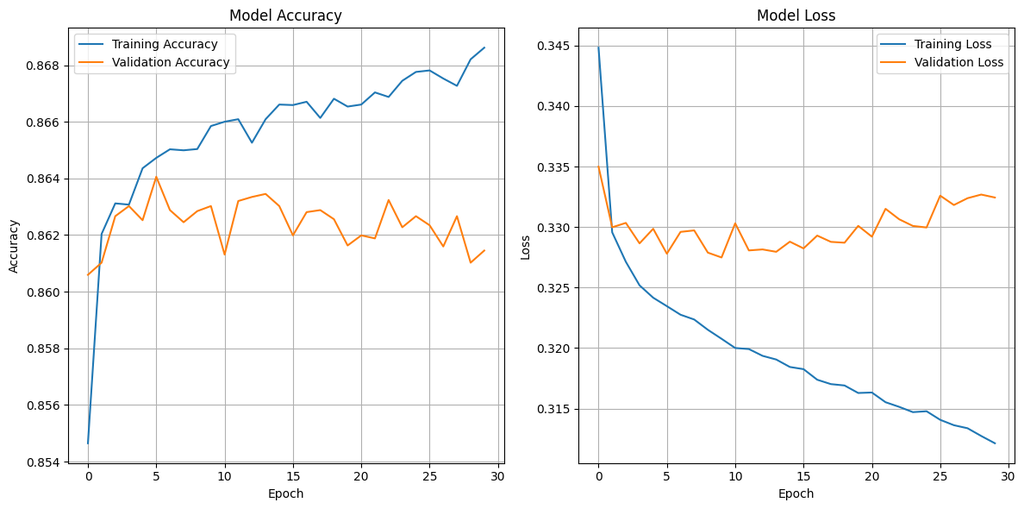

```python
plt.figure(figsize=(12, 6))
plt.subplot(1, 2, 1)
plt.plot(m.history['accuracy'], label='Training Accuracy')
plt.plot(m.history['val_accuracy'], label='Validation Accuracy')
plt.title('Model Accuracy')
plt.xlabel('Epoch')
plt.ylabel('Accuracy')
plt.legend()
plt.grid(True)

plt.subplot(1, 2, 2)
plt.plot(m.history['loss'], label='Training Loss')
plt.plot(m.history['val_loss'], label='Validation Loss')
plt.title('Model Loss')
plt.xlabel('Epoch')
plt.ylabel('Loss')
plt.legend()
plt.grid(True)
plt.tight_layout()
plt.show()
```

✅ Task 14: Save and Load the Model (Optional)

📄 Report Questions (To be submitted separately)

- Dataset Selection: What dataset did you choose? Describe its purpose and target.
- EDA Findings: What key insights did you gain during EDA?
- Feature Engineering: What transformations did you apply? Why?
- ANN Architecture: List number of layers, neurons, activation functions.
- Performance Summary: What were the final accuracy and loss?
- Confusion Matrix Analysis: What did it reveal about model behavior?
- Hyperparameter Tuning: What parameters did you change and what was the result?
- Improvement Ideas: Suggest one way to improve performance.
- Overfitting/Underfitting: Did you face it? How did you address it?